# Introduction to R

Michael Barrows

2020-08-18

## Adgenda

1. What is R
2. Suggested Workflow
3. Document Types
4. Style Guide
5. Packages

# 1. What is R

## Origin

- Developed in 1995 at the University of Auckland, New Zealand
- Derivative of the S language developed by Bell Laboratories (Formerly AT&T)

## Free and Open Source

- 100% free
- Active development
- Code transparency

## Enhanced Reproducitility

- Run reports the same way every time
- Not just calculations but figures and documenation as well

## Reporting Flexibility

- HTML
- PDF
- Web Apps
- Slideshows
- Much more!

## Great support

- Many online communities
- Open source means quick, colaborative changes
- Great primary and third-party documentation

## Competitors

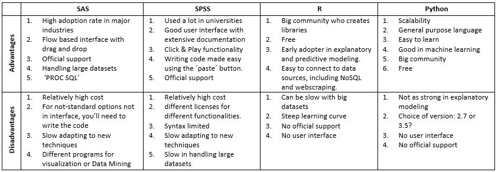

## Recap

- R developed in 1995
- Free, Open Source, and Powerful
- Enables incredible reproducibility and flexibility
- Tremendous support in multiple places
- Good, but not the only option

# 2. Suggested Workflow

## Projects

[figure not shown]

- Self-contained
- Portable
- Open with one file
- Start one with each new **Project**

## Packrat

- Save your package library information
- Make sharing projects easier and more reliable
- Like projects, do it from the get-go

## Github

[figure not shown]

- Yet another step towards reproducibility
- When using Projects and Packrat this is the next logical step
- Options for public/private repositories
- Potential for Enterprise level integration

## Recap

1. Project
2. Packrat
3. SourceControl

# 3. Document Types

## Scripts

```r
variable <- "Hello"
pair <- "World!"
paste(variable, pair, sep = " ")
```

```
## [1] "Hello World!"
```

- .R file extension
- Simple top-to-bottom execution
- Can be ran in GUI or Console
- Usually for stats analysis and data manipulation

## RMarkdown

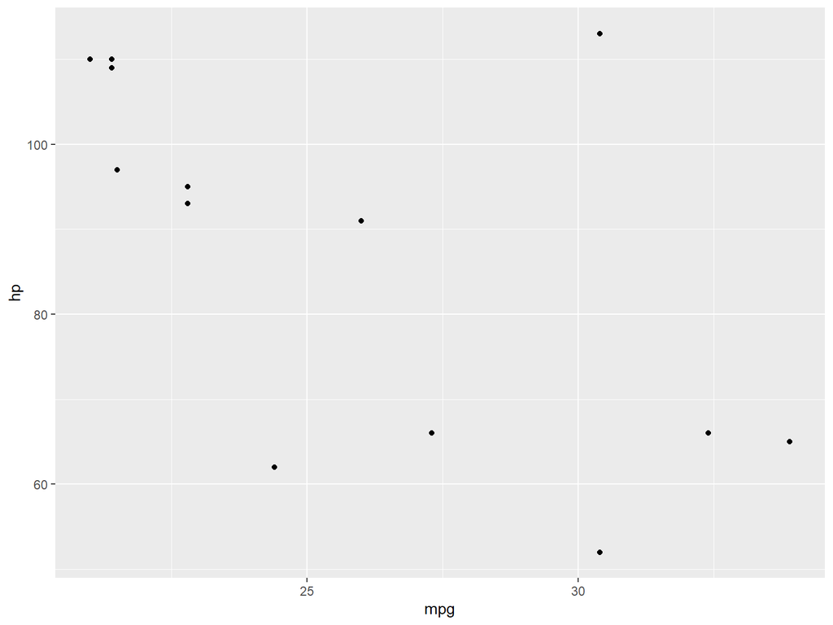

```r
mtcars %>% filter(mpg > 20) %>%
  ggplot(.,aes(mpg,hp)) + geom_point()
```

- .RMD file extension
- Add your code and results to a markdown document
- Can create many output file formats
- This presentation was written in an RMD file
- Mostly standard markdown language

[figure not shown]

- .RMD file extension
- Add your code and results to a markdown document
- Can create many output file formats
- This presentation was written in an RMD file
- Mostly common markdown language

## Shiny Apps

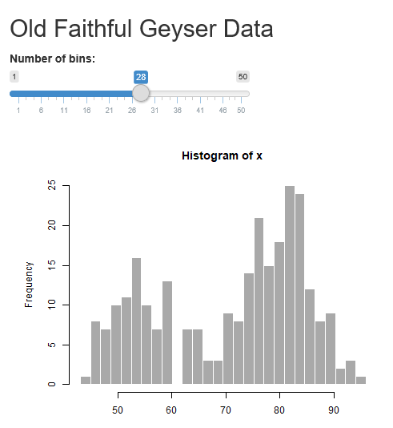

- Interactive and Reactive data manipulation
- Must be running on an R instance (client or server)
- Great for data exploration

## Recap

- Scripts = simple and repeatable
- RMarkdown = Code + Documentation
- Shiny = Interactive

# 4. Style Guide

## Assignment

```r
value -> 25 #WRONG

value = 25 #Generally bad

value <- 25 #Correct
```

- use the left arrow (<-) operator
- equal sign is used in comparrisons
- variable on the left value on the right

## Naming

```r
1stValue <- "Not Allowed"

val2 <- 1 + 2 # BAD

firstValue <- 1 + 2 # Better

Total_Time_ms <- 1 + 2 # Best
```

- Underscores
- Descriptive
- Include Units
- Can’t start with a number

## Spacing and Syntax

```r
Total_Time_ms_bad<-(5*3)+1-4 # BAD

Total_Time_ms_good <- (5*3) + 1 - 4 # Good

Comparisson_Bad <- TRUE>1|TRUE==FALSE # BAD

Comparisson_good <- TRUE > 1 | TRUE == FALSE #GOOD
```

- spaces between arithmatic operators
- spaces between comparisson operators
- Use R Studio’s built-in syntax checker

## Recap

- Assign to the left
- Spaces Everywhere
- Descriptive Names with Underscores

# 5. Packages

## What are they?

- Small Addons that increase functionality
- Usually targeted at one specific purpose (cleaning, stats method, etc.)
- Must be installed AND loaded before use

```r
install.packages('ggplot2')
library(ggplot2)
```

## Popular packages

- ggplot2 (plotting)
- plotly (interactive plotting)
- dplyr (Data Transformations)
- readxl (.xlsx importing)
- mass (various statistics functions/datasets)
- car (**C**ompanion to **A**pplied **R**egression)

## [Tidyverse](https://www.tidyverse.org/)

[figure not shown]

- Package of packages
- Everything you need to get started with data cleaning
- Be careful, large and takes a while to install
- Unified syntax and strong compatibility

# 6. Summary

- R is Free, Open source, and enables reproducibility
- Projects -> Packrat -> Source Control
- Scrips, RMarkdown, Shiny
- Spacing, Description, left-assignment
- Packages add functionality